# Binary Logistic Regression

Mariam Walaa

```r
library(MASS)
library(broom)
library(corrplot)
library(tidyverse)
```

### Data

This data set comes from the UCI Machine Learning Repository and can be found [here](https://archive.ics.uci.edu/ml/datasets/wine+quality). According to the data abstract, this data set consists of red vinho verde wine samples from the north of Portugal. The purpose of this data set is to model wine quality based on physicochemical tests. This data set contains one integer variable and the remaining variables are doubles. There are 1,599 red wine samples and 12 variables describing each sample. There are no missing values in this data set. The dependent variable is wine quality.

```r
wine <- read.csv(file = '../data/Wine/winequality-red.csv', sep = ';')
```

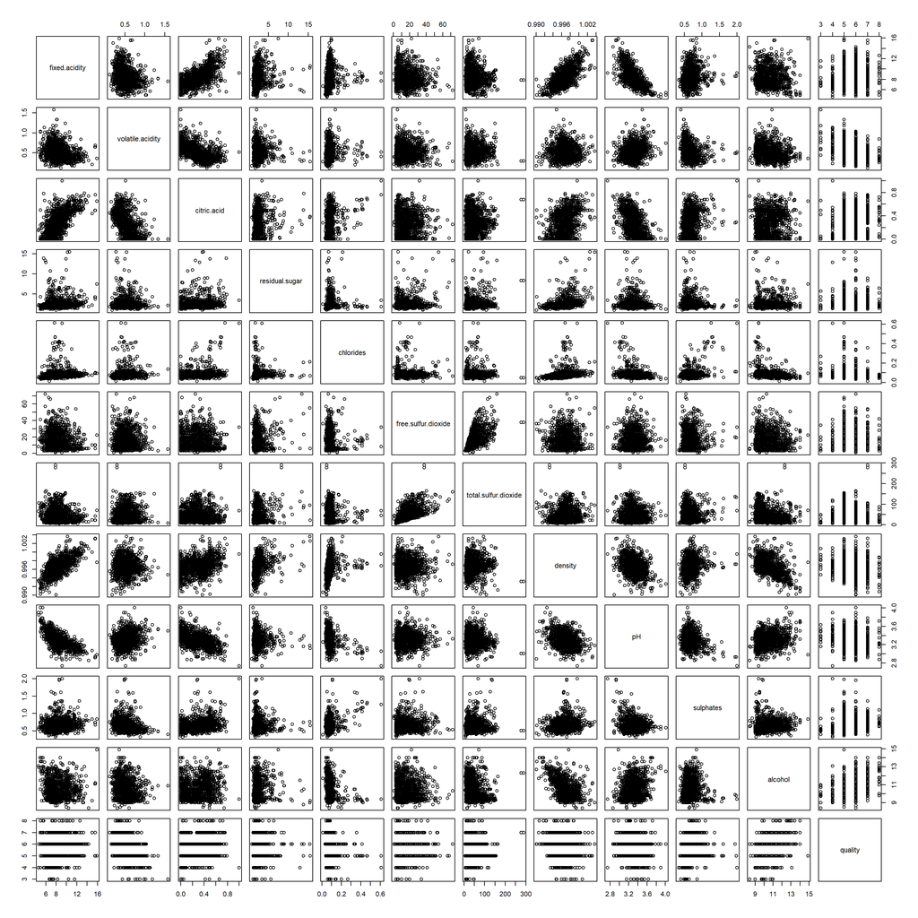

```r
plot(wine)
```

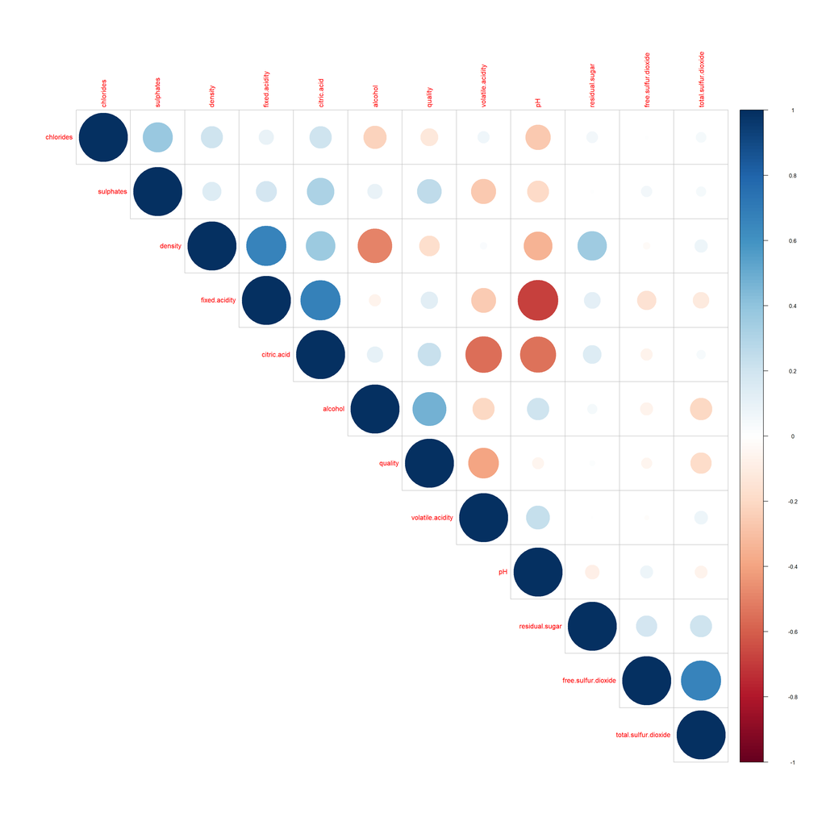

```r
wine %>%
  cor() %>%
  corrplot(type = "upper", order = "hclust")
```

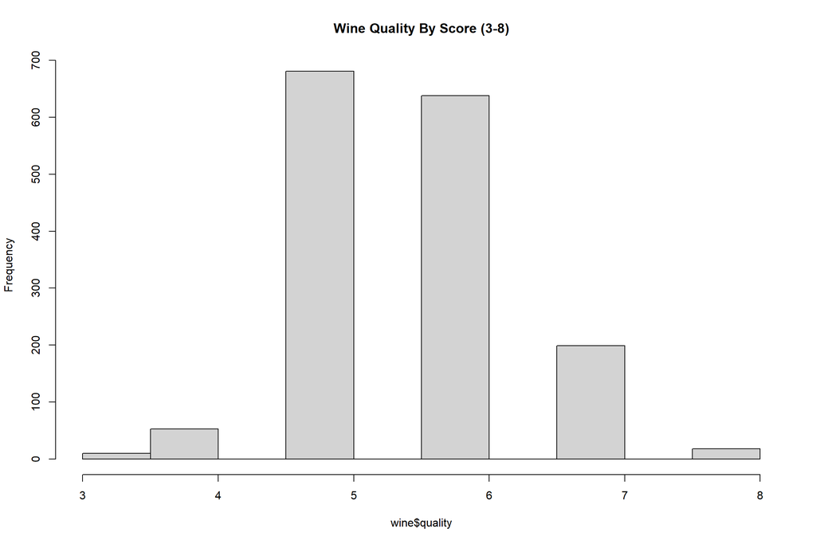

```r
hist(wine$quality, main = "Wine Quality By Score (3-8)")
```

Most wines have a score of 5 or 6 for quality.

```r
wine$quality <- ifelse(wine$quality > 6, 1, 0)
```

Any wines with a score > 6 is considered to be of good quality.

```r
stepAIC(glm(quality ~.,
            data = wine,
            family = binomial(link = 'logit')),
        trace = FALSE)$anova
```

```
## Stepwise Model Path
## Analysis of Deviance Table
##
## Initial Model:
## quality ~ fixed.acidity + volatile.acidity + citric.acid + residual.sugar +
##     chlorides + free.sulfur.dioxide + total.sulfur.dioxide +
##     density + pH + sulphates + alcohol
##
## Final Model:
## quality ~ fixed.acidity + volatile.acidity + residual.sugar +
##     chlorides + total.sulfur.dioxide + density + sulphates +
##     alcohol
##
##
##                    Step Df   Deviance Resid. Df Resid. Dev      AIC
## 1                                          1587   870.8644 894.8644
## 2                  - pH  1 0.05033176      1588   870.9148 892.9148
## 3         - citric.acid  1 0.41822777      1589   871.3330 891.3330
## 4 - free.sulfur.dioxide  1 0.74302331      1590   872.0760 890.0760
```

The step AIC model selection algorithm suggests that the best model for predicting the quality of wine is the model that uses fixed acidity, volatile acidity, residual sugar, chlorides, total sulfur dioxide, density, sulphates, and alcohol to predict the quality of wine.

```r
model <- glm(quality ~
               fixed.acidity +
               volatile.acidity +
               residual.sugar +
               chlorides +
               total.sulfur.dioxide +
               density +
               sulphates +
               alcohol,
             data = wine,
             family = binomial(link = 'logit'))
```

```r
summary(model)
```

```
##
## Call:
## glm(formula = quality ~ fixed.acidity + volatile.acidity + residual.sugar +
##     chlorides + total.sulfur.dioxide + density + sulphates +
##     alcohol, family = binomial(link = "logit"), data = wine)
##
## Deviance Residuals:
##     Min       1Q   Median       3Q      Max
## -3.0158  -0.4314  -0.2220  -0.1255   2.9883
##
## Coefficients:
##                        Estimate Std. Error z value Pr(>|z|)
## (Intercept)           2.268e+02  9.163e+01   2.475 0.013336 *
## fixed.acidity         2.812e-01  8.029e-02   3.502 0.000462 ***
## volatile.acidity     -2.913e+00  6.467e-01  -4.504 6.66e-06 ***
## residual.sugar        2.328e-01  7.009e-02   3.322 0.000893 ***
## chlorides            -8.441e+00  3.259e+00  -2.590 0.009593 **
## total.sulfur.dioxide -1.360e-02  3.447e-03  -3.946 7.95e-05 ***
## density              -2.409e+02  9.202e+01  -2.618 0.008835 **
## sulphates             3.699e+00  5.287e-01   6.997 2.62e-12 ***
## alcohol               7.823e-01  1.120e-01   6.983 2.88e-12 ***
## ---
## Signif. codes:  0 '***' 0.001 '**' 0.01 '*' 0.05 '.' 0.1 ' ' 1
##
## (Dispersion parameter for binomial family taken to be 1)
##
##     Null deviance: 1269.92  on 1598  degrees of freedom
## Residual deviance:  872.08  on 1590  degrees of freedom
## AIC: 890.08
##
## Number of Fisher Scoring iterations: 6
```

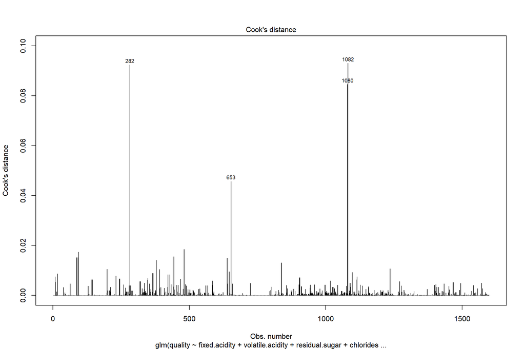

```r
plot(model, which = 4, id.n = 4)
```

There are 4 values that have a much larger Cook’s distance than the rest.

```r
augment(model) %>%
  mutate(index = 1:n()) %>%
  top_n(4, .cooksd) %>%
  dplyr::select(index, .resid, .std.resid, .cooksd)
```

```
## # A tibble: 4 x 4
##   index .resid .std.resid .cooksd
##   <int>  <dbl>      <dbl>   <dbl>
## 1   282   2.37       2.43  0.0924
## 2   653  -3.02      -3.02  0.0457
## 3  1080   2.05       2.14  0.0846
## 4  1082   2.11       2.21  0.0931
```

Only 1 of these values has a standardized residual greater than 3. All have very small Cook’s distances.

```r
round(exp(coef(model)), 3)
```

```
##          (Intercept)        fixed.acidity     volatile.acidity
##         2.995201e+98         1.325000e+00         5.400000e-02
##       residual.sugar            chlorides total.sulfur.dioxide
##         1.262000e+00         0.000000e+00         9.860000e-01
##              density            sulphates              alcohol
##         0.000000e+00         4.039600e+01         2.186000e+00
```

```r
round(exp(confint(model)), 3)
```

```
##                             2.5 %        97.5 %
## (Intercept)          5.580631e+20 9.590413e+176
## fixed.acidity        1.132000e+00  1.552000e+00
## volatile.acidity     1.500000e-02  1.890000e-01
## residual.sugar       1.094000e+00  1.443000e+00
## chlorides            0.000000e+00  5.600000e-02
## total.sulfur.dioxide 9.800000e-01  9.930000e-01
## density              0.000000e+00  0.000000e+00
## sulphates            1.432600e+01  1.151380e+02
## alcohol              1.759000e+00  2.731000e+00
```

Most of the confidence intervals for each independent variable are not too wide with exception to sulphates.